# hw8

Austin Melendez

2026-04-09

Section 8.4: Exercises 8, 9

## Exercise 8

In the lab, a classification tree was applied to the `Carseats` data set after converting `Sales` into a qualitative response variable. Now we will seek to predict `Sales` using regression trees and related approaches, treating the response as a quantitative variable.

```r
#install.packages("ISLR2")
#install.packages("tree")
#install.packages("randomForest")
#install.packages("BART")

library(ISLR2)
library(tree)
set.seed(1)

data(Carseats)
```

### A

Split into training and test set.

```r
train <- sample(1:nrow(Carseats), nrow(Carseats)/2)
Carseats_train <- Carseats[train, ]
Carseats_test  <- Carseats[-train, ]
```

### B

Fit a regression tree to the training set. Plot the tree and interpret the results.

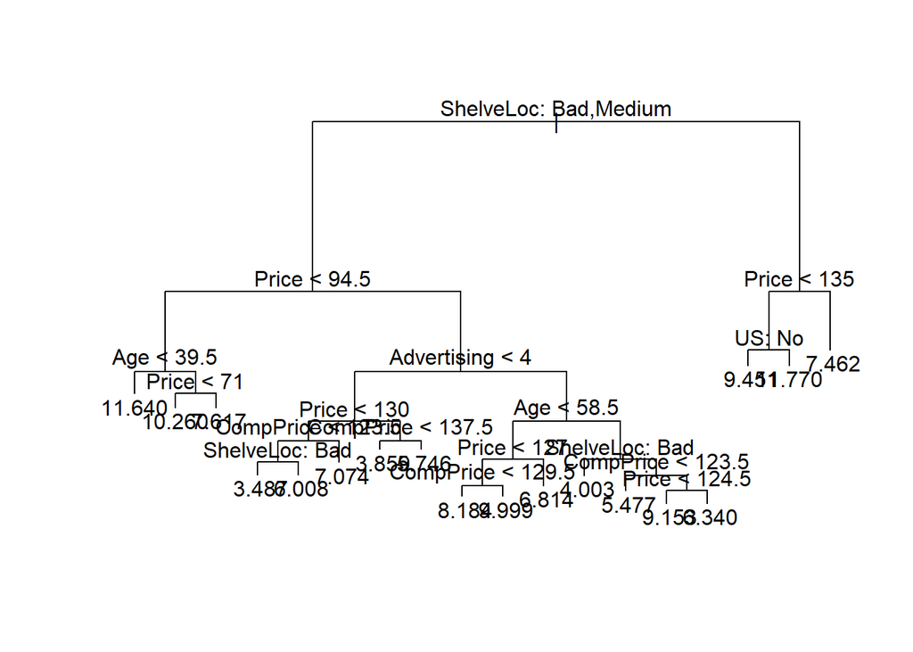

```r
tree_fit <- tree(Sales ~ ., data = Carseats_train)

# Plot tree
plot(tree_fit)
text(tree_fit, pretty = 0)
```

```r
tree_pred <- predict(tree_fit, newdata = Carseats_test)

# Test MSE
mean((tree_pred - Carseats_test$Sales)^2)
```

```
## [1] 4.922039
```

### C

Use cross-validation to determine the optimal level of tree complexity. Does pruning the tree improve the test MSE?

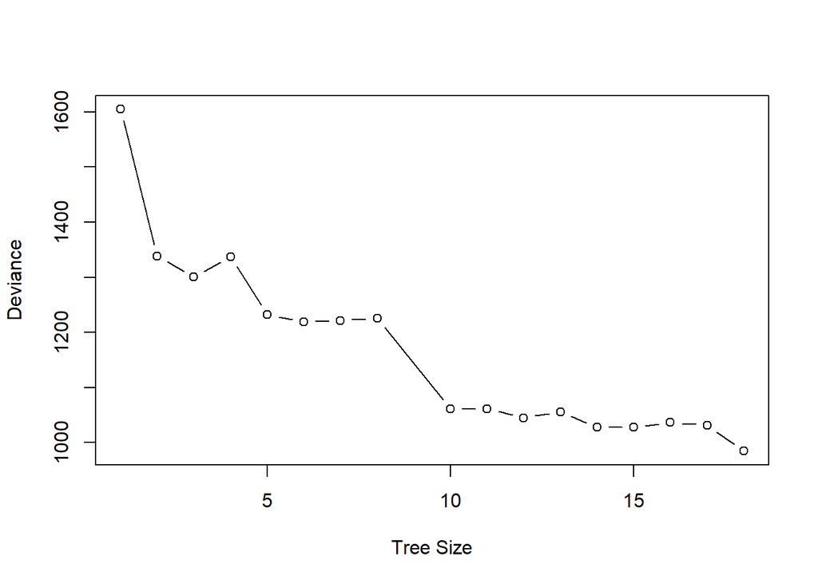

```r
set.seed(1)

cv_tree <- cv.tree(tree_fit)

# Plot CV results
plot(cv_tree$size, cv_tree$dev, type = "b",
     xlab = "Tree Size", ylab = "Deviance")
```

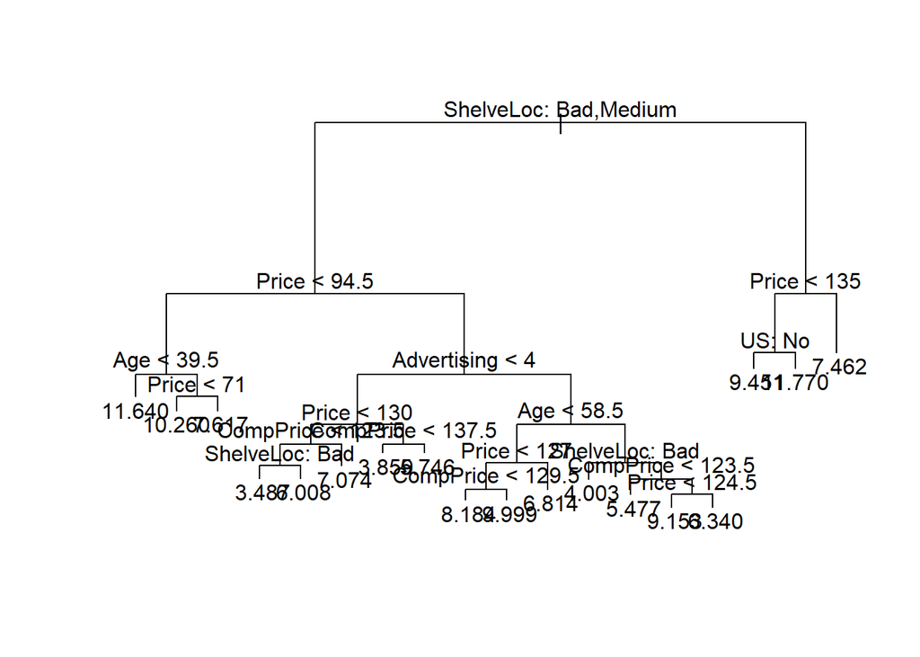

```r
# Find best size using CV
best_size <- cv_tree$size[which.min(cv_tree$dev)]

# Prune tree
pruned_tree <- prune.tree(tree_fit, best = best_size)

# Plot pruned tree
plot(pruned_tree)
text(pruned_tree, pretty = 0)
```

```r
# Test MSE
pruned_pred <- predict(pruned_tree, newdata = Carseats_test)
mean((pruned_pred - Carseats_test$Sales)^2)
```

```
## [1] 4.922039
```

### D

Use the bagging approach. What test MSE do you obtain? Use `importance()` to determine which variables are most important.

```r
library(randomForest)
set.seed(1)

bag_fit <- randomForest(Sales ~ ., data = Carseats_train,
                        mtry = ncol(Carseats_train) - 1,
                        importance = TRUE)

# Predictions
bag_pred <- predict(bag_fit, newdata = Carseats_test)

# Test MSE
mean((bag_pred - Carseats_test$Sales)^2)
```

```
## [1] 2.605253
```

```r
# Variable importance
importance(bag_fit)
```

```
##                %IncMSE IncNodePurity
## CompPrice   24.8888481    170.182937
## Income       4.7121131     91.264880
## Advertising 12.7692401     97.164338
## Population  -1.8074075     58.244596
## Price       56.3326252    502.903407
## ShelveLoc   48.8886689    380.032715
## Age         17.7275460    157.846774
## Education    0.5962186     44.598731
## Urban        0.1728373      9.822082
## US           4.2172102     18.073863
```

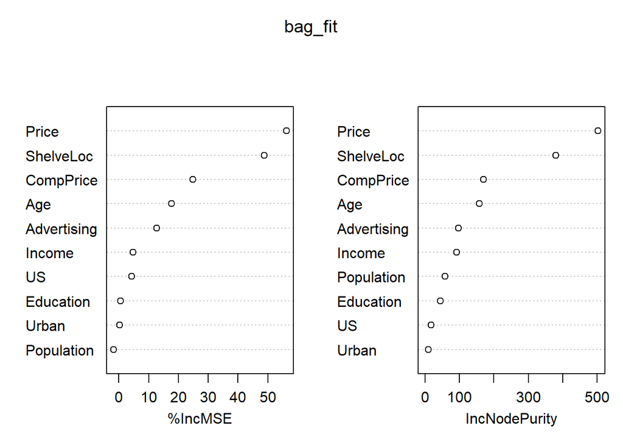

```r
varImpPlot(bag_fit)
```

### E

Use random forests. What test MSE do you obtain? Use `importance()` to determine which variables are most important. Describe the effect of $m$, the number of variables onsidered at each split, and the error rate obtained.

```r
set.seed(1)

rf_fit <- randomForest(Sales ~ ., data = Carseats_train,
                       mtry = floor(sqrt(ncol(Carseats_train) - 1)),
                       importance = TRUE)

# Predictions
rf_pred <- predict(rf_fit, newdata = Carseats_test)

# Test MSE
mean((rf_pred - Carseats_test$Sales)^2)
```

```
## [1] 2.960559
```

```r
# Importance
importance(rf_fit)
```

```
##                %IncMSE IncNodePurity
## CompPrice   14.8840765     158.82956
## Income       4.3293950     125.64850
## Advertising  8.2215192     107.51700
## Population  -0.9488134      97.06024
## Price       34.9793386     385.93142
## ShelveLoc   34.9248499     298.54210
## Age         14.3055912     178.42061
## Education    1.3117842      70.49202
## Urban       -1.2680807      17.39986
## US           6.1139696      33.98963
```

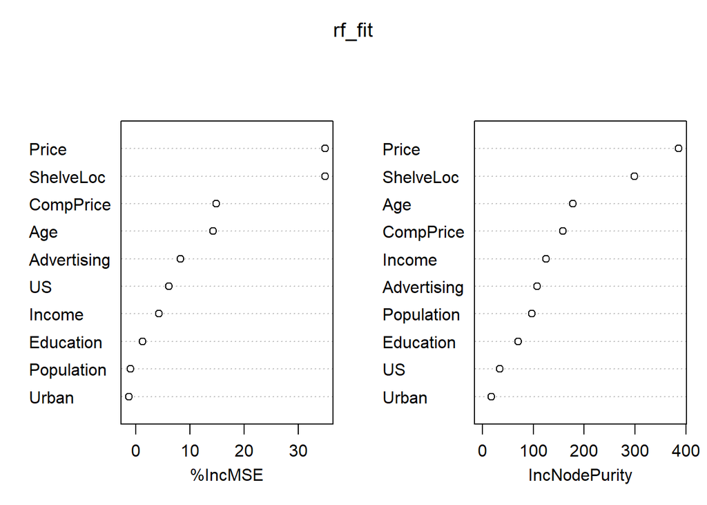

```r
varImpPlot(rf_fit)
```

### F

Analyze the data using BART.

```r
library(BART)
set.seed(1)

# Prepare matrices
x_train <- model.matrix(Sales ~ . - 1, data = Carseats_train)
y_train <- Carseats_train$Sales
x_test  <- model.matrix(Sales ~ . - 1, data = Carseats_test)

# Fit BART
bart_fit <- gbart(x_train, y_train, x_test)
```

[output not shown]

```r
# Predictions
bart_pred <- bart_fit$yhat.test.mean

# Test MSE
mean((bart_pred - Carseats_test$Sales)^2)
```

```
## [1] 1.432639
```

## Exercise 9

This problem invovles the `OJ` data set which is part of the `ISLR2` package.

```r
library(ISLR2)
library(tree)

set.seed(1)

data(OJ)
```

### A

Create a training set containing a random sample of 800 observations, and a test set containing the remaining observations.

```r
train <- sample(1:nrow(OJ), 800)
OJ_train <- OJ[train, ]
OJ_test  <- OJ[-train, ]
```

### B

Fit a tree to the training data, with `Purchase` as the response and all others as predictors. What is the training error rate? How many terminal nodes does the tree have?

```r
oj_tree <- tree(Purchase ~ ., data = OJ_train)

summary(oj_tree)
```

```
##
## Classification tree:
## tree(formula = Purchase ~ ., data = OJ_train)
## Variables actually used in tree construction:
## [1] "LoyalCH"       "PriceDiff"     "SpecialCH"     "ListPriceDiff"
## [5] "PctDiscMM"
## Number of terminal nodes:  9
## Residual mean deviance:  0.7432 = 587.8 / 791
## Misclassification error rate: 0.1588 = 127 / 800
```

### C

Pick one of the terminal nodes and interpret the information displayed after typing in the name of a tree object to get a detailed text output.

```r
oj_tree
```

```
## node), split, n, deviance, yval, (yprob)
##       * denotes terminal node
##
##  1) root 800 1073.00 CH ( 0.60625 0.39375 )
##    2) LoyalCH < 0.5036 365  441.60 MM ( 0.29315 0.70685 )
##      4) LoyalCH < 0.280875 177  140.50 MM ( 0.13559 0.86441 )
##        8) LoyalCH < 0.0356415 59   10.14 MM ( 0.01695 0.98305 ) *
##        9) LoyalCH > 0.0356415 118  116.40 MM ( 0.19492 0.80508 ) *
##      5) LoyalCH > 0.280875 188  258.00 MM ( 0.44149 0.55851 )
##       10) PriceDiff < 0.05 79   84.79 MM ( 0.22785 0.77215 )
##         20) SpecialCH < 0.5 64   51.98 MM ( 0.14062 0.85938 ) *
##         21) SpecialCH > 0.5 15   20.19 CH ( 0.60000 0.40000 ) *
##       11) PriceDiff > 0.05 109  147.00 CH ( 0.59633 0.40367 ) *
##    3) LoyalCH > 0.5036 435  337.90 CH ( 0.86897 0.13103 )
##      6) LoyalCH < 0.764572 174  201.00 CH ( 0.73563 0.26437 )
##       12) ListPriceDiff < 0.235 72   99.81 MM ( 0.50000 0.50000 )
##         24) PctDiscMM < 0.196196 55   73.14 CH ( 0.61818 0.38182 ) *
##         25) PctDiscMM > 0.196196 17   12.32 MM ( 0.11765 0.88235 ) *
##       13) ListPriceDiff > 0.235 102   65.43 CH ( 0.90196 0.09804 ) *
##      7) LoyalCH > 0.764572 261   91.20 CH ( 0.95785 0.04215 ) *
```

To select a terminal node, we look for nodes that have a *, this idicates that it is a terminal node.

Node 7 corresponds to the observations where `LoyalCH` $> 0.764572$. This node contains $261$ observations and the predicted class for this node is `CH`.

It also shows us that about 95.8% of the observations purchased `CH` and 4.2% purchased `MM`.

This means that customers with a high value of `LoyalCH` are very liekly to purchase `CH`.

### D

Create a plot of the tree.

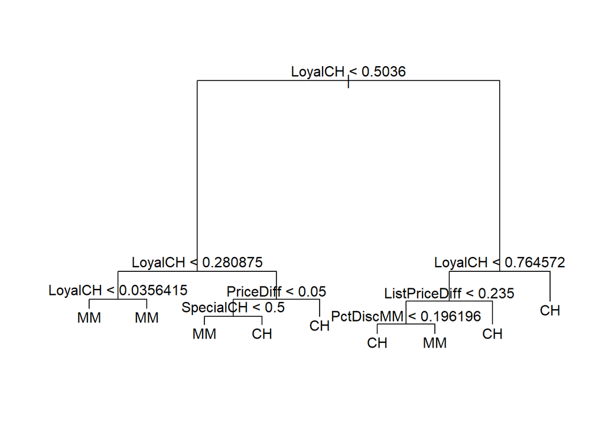

```r
plot(oj_tree)
text(oj_tree, pretty = 0)
```

### E

Predict the response on the test data, and produce a confusion matrix comparing the test labels and predicted test labels. What is the test error rate?

```r
oj_pred <- predict(oj_tree, newdata = OJ_test, type = "class")

table(oj_pred, OJ_test$Purchase)
```

```
##
## oj_pred  CH  MM
##      CH 160  38
##      MM   8  64
```

```r
# Test error rate
mean(oj_pred != OJ_test$Purchase)
```

```
## [1] 0.1703704
```

### F

Apply the `cv.tree()` function to the training set in order to determine the optimal tree size.

```r
set.seed(1)

cv_oj <- cv.tree(oj_tree, FUN = prune.tree)
```

### G

Produce a plot with tree size on the x-axis and cross-validated classification error rate on the y-axis.

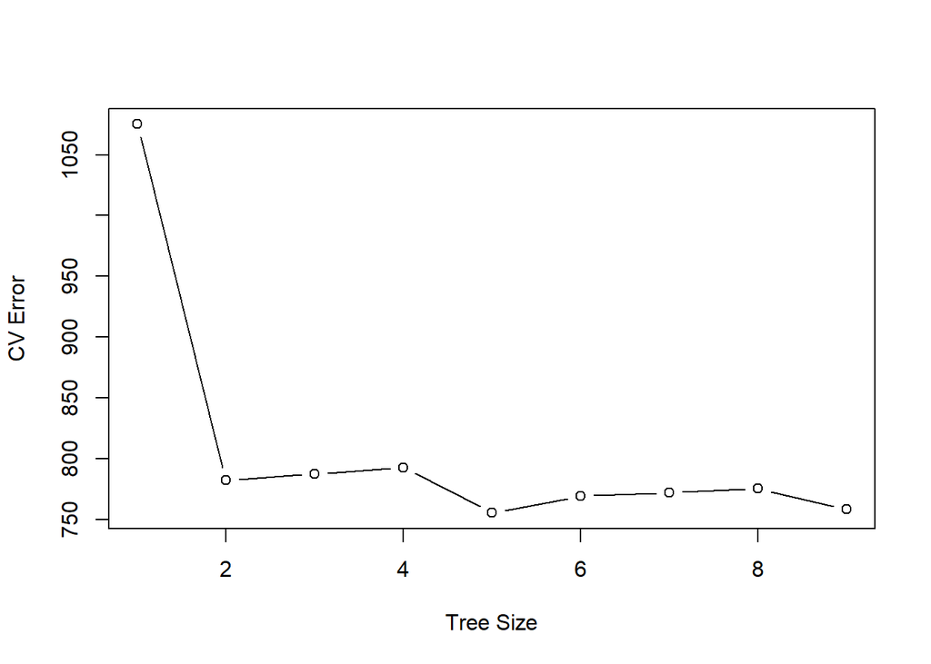

```r
plot(cv_oj$size, cv_oj$dev, type = "b",
     xlab = "Tree Size", ylab = "CV Error")
```

### H

Which tree size corresponds to the lowest cross-validated classification error rate?

```r
best_size <- cv_oj$size[which.min(cv_oj$dev)]
best_size
```

```
## [1] 5
```

### I

Produce a pruned tree corresponding to the optimal tree size obtained using CV.

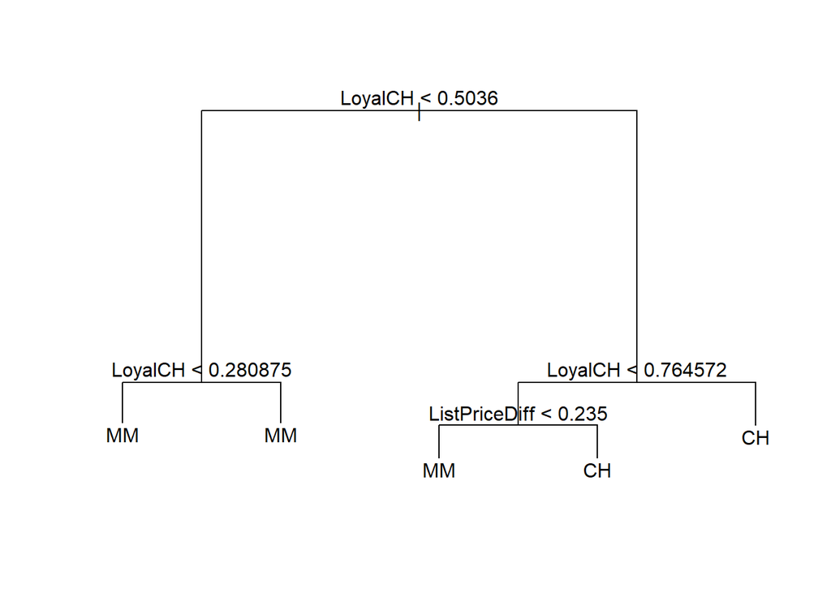

```r
pruned_oj <- prune.tree(oj_tree, best = best_size)

plot(pruned_oj)
text(pruned_oj, pretty = 0)
```

### J

Compare the training error rates between the pruned and unpruned trees. Which is higher?

```r
# Unpruned
train_pred_unpruned <- predict(oj_tree, type = "class")
mean(train_pred_unpruned != OJ_train$Purchase)
```

```
## [1] 0.15875
```

```r
# Pruned
train_pred_pruned <- predict(pruned_oj, type = "class")
mean(train_pred_pruned != OJ_train$Purchase)
```

```
## [1] 0.20125
```

The pruned tree’s training error is higher than the unpruned tree.

### K

Compare the test error rates between the pruned and unpruned trees. Which is higher?

```r
# Unpruned
test_pred_unpruned <- predict(oj_tree, newdata = OJ_test, type = "class")
mean(test_pred_unpruned != OJ_test$Purchase)
```

```
## [1] 0.1703704
```

```r
# Pruned
test_pred_pruned <- predict(pruned_oj, newdata = OJ_test, type = "class")
mean(test_pred_pruned != OJ_test$Purchase)
```

```
## [1] 0.1740741
```

The pruned tree’s test error rate is very slightly higher than the unpruned tree.